# Applied Methods in Statistics Final Project

Hotel Booking Cancellation Prediction

Ching-Yeh Chen (ID: 313554049)

2025-06-04

# 1 Problem Statement

## 1.1 Objective Description

This study aims to predict whether a hotel booking will be canceled based on customer reservation information. The dataset includes various booking-related attributes such as check-in date, number of guests, length of stay, and more. The overall research pipeline consists of data preprocessing, feature selection, dataset splitting, model construction, and model evaluation. The final output is a binary prediction indicating whether the booking will be canceled.

## 1.2 Evaluation Metrics

We define the **positive class** as canceled bookings and the **negative class** as non-canceled bookings. Based on this definition, the confusion matrix shown in **Table 1.1** summarizes the relationship between actual and predicted labels. The following metrics are used for model evaluation:

- **Accuracy**: Overall correctness of predictions
  $$\text{Accuracy} = \frac{TP + TN}{TP + TN + FP + FN}$$
- **Precision**: Correctness among all predicted cancellations
  $$\text{Precision} = \frac{TP}{TP + FP}$$
- **Recall (Sensitivity)**: Proportion of actual cancellations that were correctly identified
  $$\text{Recall} = \frac{TP}{TP + FN}$$
- **AUC (Area Under the ROC Curve)**: Area under the receiver operating characteristic curve

Table 1.1: Confusion Matrix for the Prediction Task

| Actual.Class | Predicted..Is.Canceled | Predicted..Not.Canceled |
| --- | --- | --- |
| Is Canceled | TP | FN |
| Not Canceled | FP | TN |

## 1.3 Baseline Model Performance and Target Metrics

- **Accuracy**: ≥ 0.85
- **Precision**: ≥ 0.85
- **Recall (Sensitivity)**: ≥ 0.80
- **AUC**: ≥ 0.90

Table 1.2: Model Performance from Reference Study

| Hotel | Dataset | Acc. | AUC | Prec. | Sensit. |
| --- | --- | --- | --- | --- | --- |
| H1 | Train | 0.846 | 0.910 | 0.839 | 0.626 |
| H1 | Test | 0.842 | 0.877 | 0.811 | 0.603 |
| H2 | Train | 0.857 | 0.934 | 0.876 | 0.793 |
| H2 | Test | 0.849 | 0.922 | 0.869 | 0.779 |

# 2 Dataset Description and Data Preprocessing

## 2.1 Loading Dataset

This section loads the hotel booking dataset from a CSV file into the R environment. A basic statistical summary is generated to get an initial understanding of the data distribution and identify potential anomalies or missing values.

```r
df <- read.csv("hotel_bookings.csv")
summary(df)
```

```
##     hotel            is_canceled       lead_time   arrival_date_year
##  Length:119390      Min.   :0.0000   Min.   :  0   Min.   :2015
##  Class :character   1st Qu.:0.0000   1st Qu.: 18   1st Qu.:2016
##  Mode  :character   Median :0.0000   Median : 69   Median :2016
##                     Mean   :0.3704   Mean   :104   Mean   :2016
##                     3rd Qu.:1.0000   3rd Qu.:160   3rd Qu.:2017
##                     Max.   :1.0000   Max.   :737   Max.   :2017
##
##  arrival_date_month arrival_date_week_number arrival_date_day_of_month
##  Length:119390      Min.   : 1.00            Min.   : 1.0
##  Class :character   1st Qu.:16.00            1st Qu.: 8.0
##  Mode  :character   Median :28.00            Median :16.0
##                     Mean   :27.17            Mean   :15.8
##                     3rd Qu.:38.00            3rd Qu.:23.0
##                     Max.   :53.00            Max.   :31.0
##
##  stays_in_weekend_nights stays_in_week_nights     adults
##  Min.   : 0.0000         Min.   : 0.0         Min.   : 0.000
##  1st Qu.: 0.0000         1st Qu.: 1.0         1st Qu.: 2.000
##  Median : 1.0000         Median : 2.0         Median : 2.000
##  Mean   : 0.9276         Mean   : 2.5         Mean   : 1.856
##  3rd Qu.: 2.0000         3rd Qu.: 3.0         3rd Qu.: 2.000
##  Max.   :19.0000         Max.   :50.0         Max.   :55.000
##
##     children           babies              meal             country
##  Min.   : 0.0000   Min.   : 0.000000   Length:119390      Length:119390
##  1st Qu.: 0.0000   1st Qu.: 0.000000   Class :character   Class :character
##  Median : 0.0000   Median : 0.000000   Mode  :character   Mode  :character
##  Mean   : 0.1039   Mean   : 0.007949
##  3rd Qu.: 0.0000   3rd Qu.: 0.000000
##  Max.   :10.0000   Max.   :10.000000
##  NA's   :4
##  market_segment     distribution_channel is_repeated_guest
##  Length:119390      Length:119390        Min.   :0.00000
##  Class :character   Class :character     1st Qu.:0.00000
##  Mode  :character   Mode  :character     Median :0.00000
##                                          Mean   :0.03191
##                                          3rd Qu.:0.00000
##                                          Max.   :1.00000
##
```

[output cut: 25 more lines]

```
##  Min.   :0.00000             Min.   :0.0000            Length:119390
##  1st Qu.:0.00000             1st Qu.:0.0000            Class :character
##  Median :0.00000             Median :0.0000            Mode  :character
##  Mean   :0.06252             Mean   :0.5714
##  3rd Qu.:0.00000             3rd Qu.:1.0000
##  Max.   :8.00000             Max.   :5.0000
##
##  reservation_status_date
##  Length:119390
##  Class :character
##  Mode  :character
##
##
##
##
```

## 2.2 Data Source

The dataset used in this project originates from Kaggle and has also been published in a peer-reviewed article. It contains real-world hotel booking records, making it suitable for cancellation prediction and customer behavior analysis.

- Kaggle: [Hotel Booking Demand Dataset](https://www.kaggle.com/datasets/jessemostipak/hotel-booking-demand)
- Original publication [[2]]: [ScienceDirect](https://www.sciencedirect.com/science/article/pii/S2352340918315191)

## 2.3 Dataset Overview

This section summarizes the key attributes of the dataset, including the number of records, the time range covered, and the total number of features. The dataset includes both categorical and numerical variables related to bookings, customer behavior, and hotel types.

- Total records: **119,390**
- Time range: **2015–2017**
- Total features: **32 columns**

Table 2.1: Dataset Columns and Their Data Types

| Columns | Data Type | Columns | Data Type |
| --- | --- | --- | --- |
| hotel | object (2) | is_repeated_guest | int64 |
| is_canceled | int64 | previous_cancellations | int64 |
| lead_time | int64 | previous_bookings_not_canceled | int64 |
| arrival_date_year | int64 | reserved_room_type | object (10) |
| arrival_date_month | object (12) | assigned_room_type | object (12) |
| arrival_date_week_number | int64 | booking_changes | int64 |
| arrival_date_day_of_month | int64 | deposit_type | object (3) |
| stays_in_weekend_nights | int64 | agent | float64 |
| stays_in_week_nights | int64 | company | float64 |
| adults | int64 | days_in_waiting_list | int64 |
| children | float64 | customer_type | object (4) |
| babies | int64 | adr | float64 |
| meal | object (5) | required_car_parking_spaces | int64 |
| country | object (178) | total_of_special_requests | int64 |
| market_segment | object (8) | reservation_status | object (3) |
| distribution_channel | object (5) | reservation_status_date | object |

## 2.4 Creating a Unified Arrival Date Column

The dataset provides year, month (in string format), and day as separate columns. To streamline time-based analysis, we convert these columns into a single arrival_date column of Date type. This step simplifies later aggregation and time-series visualization.

```r
# Define a mapping from month names to numeric values (e.g., "January" -> 1)
month_mapping <- c(
  "January" = 1, "February" = 2, "March" = 3, "April" = 4,
  "May" = 5, "June" = 6, "July" = 7, "August" = 8,
  "September" = 9, "October" = 10, "November" = 11, "December" = 12
)

# Convert 'arrival_date_month' from month name (e.g., "July") to numeric (e.g., 7)
df$arrival_date_month <- as.integer(month_mapping[df$arrival_date_month])

# Construct a proper Date object by combining year, numeric month, and day
# Use sprintf to ensure two-digit formatting for month and day (e.g., 07, 01)
df$arrival_date <- as.Date(
  paste(
    df$arrival_date_year,
    sprintf("%02d", df$arrival_date_month),
    sprintf("%02d", df$arrival_date_day_of_month),
    sep = "-"
  ),
  format = "%Y-%m-%d"
)

# Remove the original separate year/month/day columns after creating 'arrival_date'
#df <- subset(df, select = -c(arrival_date_year, arrival_date_month, arrival_date_day_of_month))

# Preview the transformed dataset
head(df)
```

```
##          hotel is_canceled lead_time arrival_date_year arrival_date_month
## 1 Resort Hotel           0       342              2015                  7
## 2 Resort Hotel           0       737              2015                  7
## 3 Resort Hotel           0         7              2015                  7
## 4 Resort Hotel           0        13              2015                  7
## 5 Resort Hotel           0        14              2015                  7
## 6 Resort Hotel           0        14              2015                  7
##   arrival_date_week_number arrival_date_day_of_month stays_in_weekend_nights
## 1                       27                         1                       0
## 2                       27                         1                       0
## 3                       27                         1                       0
## 4                       27                         1                       0
## 5                       27                         1                       0
## 6                       27                         1                       0
##   stays_in_week_nights adults children babies meal country market_segment
```

[output cut: 41 more lines]

## 2.5 Handling Missing Values

Handling missing values is essential to ensure model stability and accuracy. This section separates numeric and categorical variables and applies appropriate imputation strategies—median for numeric columns and mode for categorical columns.

```r
library(dplyr)

# Identify column types
numeric_columns <- names(df)[sapply(df, is.numeric)]
categorical_columns <- names(df)[sapply(df, is.character)]

# Impute numeric columns using median
df_numeric <- df %>%
  select(all_of(numeric_columns)) %>%
  mutate(across(everything(), ~ ifelse(is.na(.), median(., na.rm = TRUE), .)))

# Impute categorical columns using most frequent value (mode)
get_mode <- function(x) {
  ux <- na.omit(unique(x))
  ux[which.max(tabulate(match(x, ux)))]
}

df_categorical <- df %>%
  select(all_of(categorical_columns)) %>%
  mutate(across(everything(), ~ ifelse(is.na(.), get_mode(.), .)))

# Preserve other columns like 'arrival_date'
other_columns <- df %>%
  select(-all_of(numeric_columns), -all_of(categorical_columns))

# Combine all parts back together
df <- bind_cols(df_numeric, df_categorical, other_columns)

# Save unique values of categorical variables
unique_values <- lapply(df_categorical, unique)
names(unique_values) <- categorical_columns
```

## 2.6 Encoding Categorical Variables and Cleaning Data

Machine learning models generally require numeric input. This section transforms categorical variables into numeric format using label encoding and one-hot encoding. Additionally, columns causing data leakage or with high missingness are removed to avoid bias in prediction models.

```r
library(fastDummies)

# Label encode the 'hotel' column (Resort Hotel = 0, City Hotel = 1)
df$hotel <- ifelse(df$hotel == "Resort Hotel", 0L, 1L)

# Drop leakage-related columns
leakage_cols <- c("reservation_status", "reservation_status_date", "booking_changes")
df <- df %>% select(-all_of(leakage_cols))

# Drop high-missing or low-importance columns
df <- df %>% select(-agent, -company, -country)

# Save unique values of 'deposit_type' before encoding
unique_values[["deposit_type"]] <- unique(df$deposit_type)

# Apply one-hot encoding to selected categorical columns
df <- dummy_cols(df,
                 select_columns = c("meal", "market_segment", "distribution_channel",
                                    "reserved_room_type", "assigned_room_type",
                                    "customer_type", "deposit_type"),
                 remove_selected_columns = TRUE,
                 remove_first_dummy = FALSE)

# Convert dummy columns to integer type
dummy_columns <- names(df)[grepl("meal_|market_segment_|distribution_channel_|reserved_room_type_|assigned_room_type_|customer_type_|deposit_type_", names(df))]
df[dummy_columns] <- lapply(df[dummy_columns], as.integer)

# Final structure check
str(df)
```

```
## 'data.frame':    119390 obs. of  67 variables:
##  $ is_canceled                   : int  0 0 0 0 0 0 0 0 1 1 ...
##  $ lead_time                     : int  342 737 7 13 14 14 0 9 85 75 ...
##  $ arrival_date_year             : int  2015 2015 2015 2015 2015 2015 2015 2015 2015 2015 ...
##  $ arrival_date_month            : int  7 7 7 7 7 7 7 7 7 7 ...
##  $ arrival_date_week_number      : int  27 27 27 27 27 27 27 27 27 27 ...
##  $ arrival_date_day_of_month     : int  1 1 1 1 1 1 1 1 1 1 ...
##  $ stays_in_weekend_nights       : int  0 0 0 0 0 0 0 0 0 0 ...
##  $ stays_in_week_nights          : int  0 0 1 1 2 2 2 2 3 3 ...
##  $ adults                        : int  2 2 1 1 2 2 2 2 2 2 ...
##  $ children                      : num  0 0 0 0 0 0 0 0 0 0 ...
##  $ babies                        : int  0 0 0 0 0 0 0 0 0 0 ...
##  $ is_repeated_guest             : int  0 0 0 0 0 0 0 0 0 0 ...
##  $ previous_cancellations        : int  0 0 0 0 0 0 0 0 0 0 ...
##  $ previous_bookings_not_canceled: int  0 0 0 0 0 0 0 0 0 0 ...
```

[output cut: 53 more lines]

## 2.7 Dataset Split by Hotel Type

To facilitate comparative analysis between different types of accommodations, we divide the dataset into two subsets based on hotel category: **Resort Hotel** and **City Hotel**. This enables us to explore differences in customer behavior, cancellation patterns, and model performance across the two types.

> **Note:** The split is performed **after label encoding**, where `Resort Hotel` is encoded as `0` and `City Hotel` as `1`. This ensures consistency in data preprocessing and feature structure before applying separate models or analysis.

```r
# Split the dataset based on encoded hotel type
df_resort <- df %>% filter(hotel == 0)
df_city <- df %>% filter(hotel == 1)

write.csv(df_resort, "resort_hotel.csv", row.names = FALSE)
write.csv(df_city, "city_hotel.csv", row.names = FALSE)
```

Each subset (`df_resort`, `df_city`) can now be independently analyzed or used for model training to evaluate performance across different hotel types.

# 3 Exploratory Data Analysis

This section explores key patterns and distributions in the dataset through various visualizations. We begin with overall proportions and then examine booking cancellation behavior across hotel types and over time.

## 3.1 Proportion of Hotel Types

This figure shows the proportion of bookings between the two hotel types.

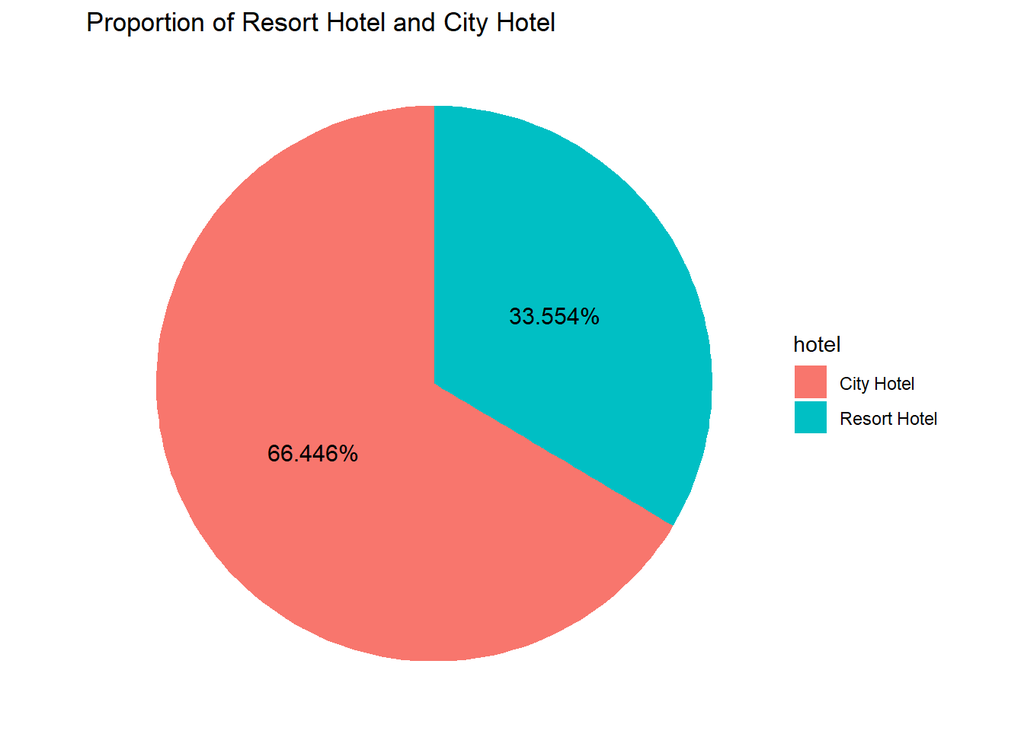

Figure 3.1: Figure 1. Proportion of Resort Hotel and City Hotel

```r
hotel_prop <- df %>%
  group_by(hotel) %>%
  summarise(count = n()) %>%
  mutate(percent = count / sum(count),
         label = paste0(round(percent * 100, 3), "%"),
         hotel = ifelse(hotel == 0, "Resort Hotel", "City Hotel"))

ggplot(hotel_prop, aes(x = "", y = percent, fill = hotel)) +
  geom_col(width = 1) +
  coord_polar(theta = "y") +
  labs(title = "Proportion of Resort Hotel and City Hotel") +
  theme_void() +
  geom_text(aes(label = label), position = position_stack(vjust = 0.5), size = 4)
```

## 3.2 Overall Booking Cancellation Proportions

This figure visualizes the overall cancellation rate across all bookings.

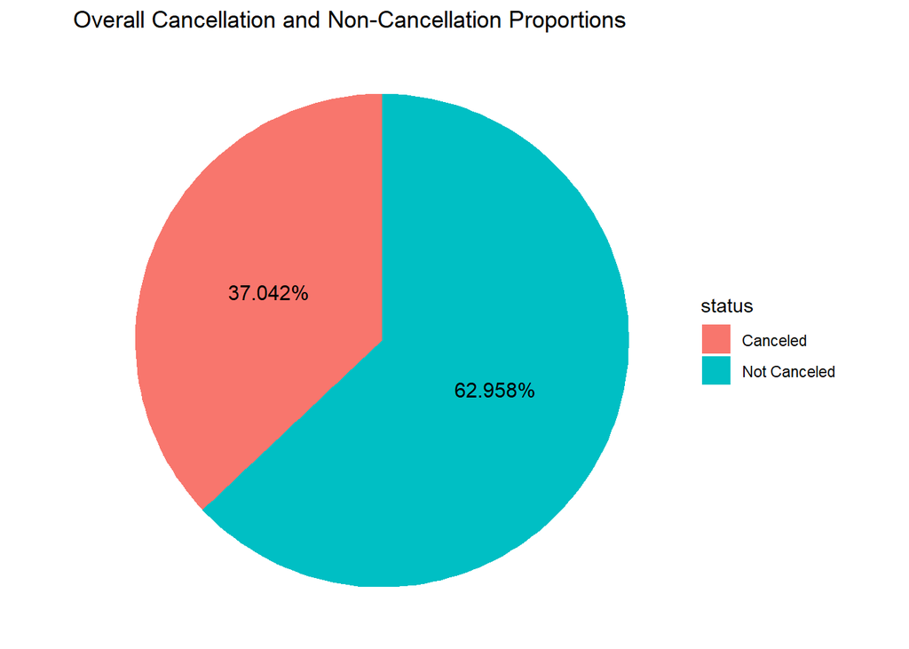

Figure 3.2: Figure 2. Overall Cancellation and Non-Cancellation Proportions

```r
cancel_prop <- df %>%
  mutate(status = ifelse(is_canceled == 1, "Canceled", "Not Canceled")) %>%
  group_by(status) %>%
  summarise(count = n()) %>%
  mutate(percent = count / sum(count),
         label = paste0(round(percent * 100, 3), "%"))

ggplot(cancel_prop, aes(x = "", y = percent, fill = status)) +
  geom_col(width = 1) +
  coord_polar(theta = "y") +
  labs(title = "Overall Cancellation and Non-Cancellation Proportions") +
  theme_void() +
  geom_text(aes(label = label), position = position_stack(vjust = 0.5), size = 4)
```

## 3.3 Resort Hotel: Cancellation vs. Non-Cancellation

This figure shows the cancellation status distribution for Resort Hotel bookings only, using the `df_resort` subset.

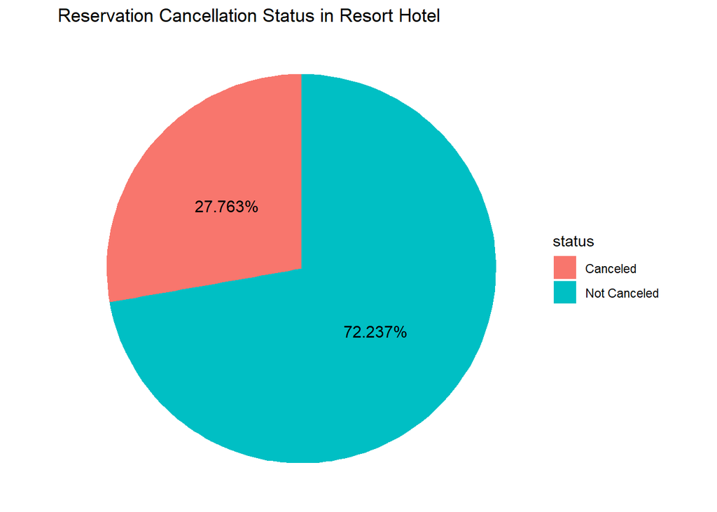

Figure 3.3: Figure 3. Reservation Cancellation Status in Resort Hotel

```r
resort_cancel <- df_resort %>%
  mutate(status = ifelse(is_canceled == 1, "Canceled", "Not Canceled")) %>%
  count(status) %>%
  mutate(percent = n / sum(n),
         label = paste0(round(percent * 100, 3), "%"))

ggplot(resort_cancel, aes(x = "", y = percent, fill = status)) +
  geom_col(width = 1) +
  coord_polar(theta = "y") +
  labs(title = "Reservation Cancellation Status in Resort Hotel") +
  theme_void() +
  geom_text(aes(label = label), position = position_stack(vjust = 0.5), size = 4)
```

## 3.4 City Hotel: Cancellation vs. Non-Cancellation

This figure shows the cancellation status distribution for City Hotel bookings only, using the `df_city` subset.

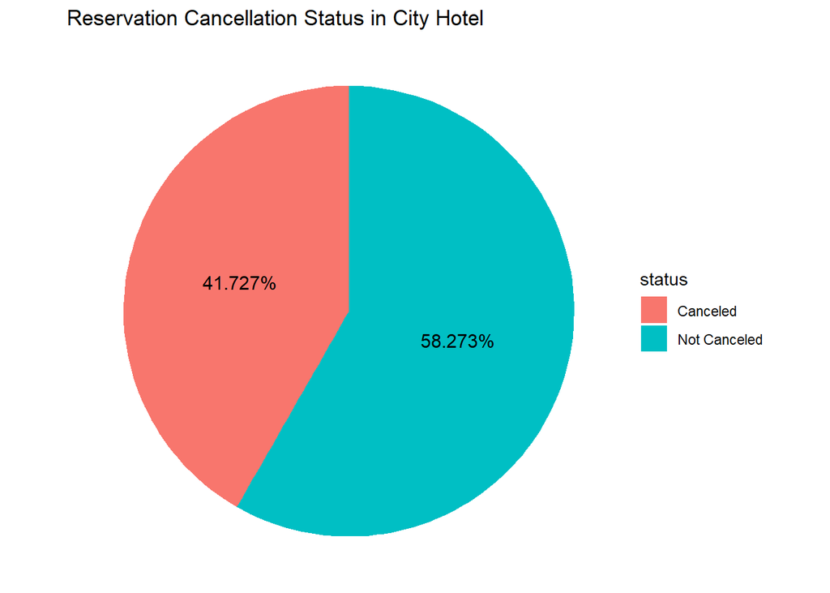

Figure 3.4: Figure 4. Reservation Cancellation Status in City Hotel

```r
city_cancel <- df_city %>%
  mutate(status = ifelse(is_canceled == 1, "Canceled", "Not Canceled")) %>%
  count(status) %>%
  mutate(percent = n / sum(n),
         label = paste0(round(percent * 100, 3), "%"))

ggplot(city_cancel, aes(x = "", y = percent, fill = status)) +
  geom_col(width = 1) +
  coord_polar(theta = "y") +
  labs(title = "Reservation Cancellation Status in City Hotel") +
  theme_void() +
  geom_text(aes(label = label), position = position_stack(vjust = 0.5), size = 4)
```

## 3.5 Reservation Counts per Year

This chart shows how the number of hotel reservations varies by arrival year.

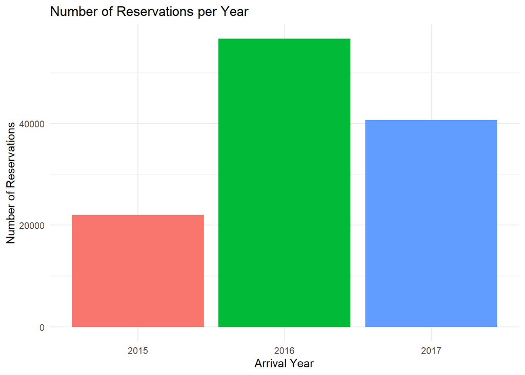

Figure 3.5: Figure 5. Number of Reservations per Year

```r
# Ensure that 'arrival_date' is in proper Date format
# If the column was previously character type, specify the date format explicitly
df$arrival_date <- as.Date(df$arrival_date, format = "%Y-%m-%d")

# Extract the year component from the date
df$year <- format(df$arrival_date, "%Y")

# Group the dataset by year and count the number of reservations per year
yearly_data <- df %>%
  group_by(year) %>%
  summarise(reservations = n())

# Create a bar plot showing the number of reservations per year
ggplot(yearly_data, aes(x = factor(year), y = reservations, fill = factor(year))) +
  geom_col() +
  labs(title = "Number of Reservations per Year",
       x = "Arrival Year",
       y = "Number of Reservations") +
  theme_minimal() +
  theme(legend.position = "none")
```

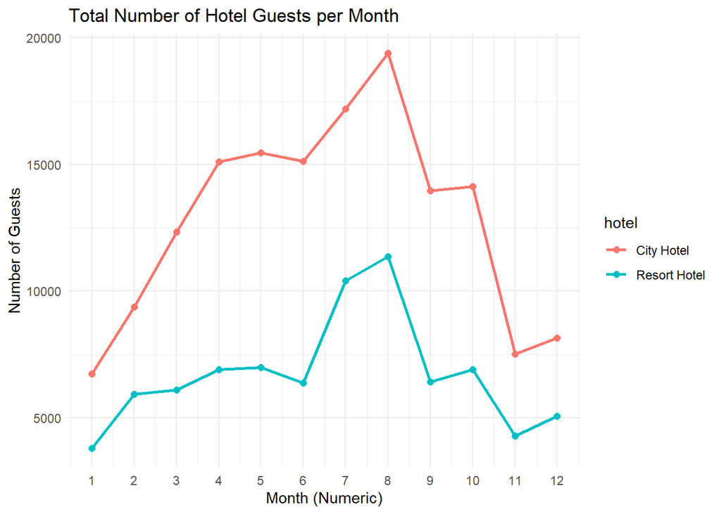

```r
# Extract numeric month from arrival_date (as integer 1~12)
df$month_num <- as.integer(format(df$arrival_date, "%m"))

# Compute total guests and monthly total per hotel type
monthly_guests <- df %>%
  mutate(total_guests = adults + children + babies) %>%
  group_by(month_num, hotel) %>%
  summarise(total_guests = sum(total_guests, na.rm = TRUE), .groups = "drop") %>%
  ungroup() %>%
  mutate(hotel = ifelse(hotel == 0, "Resort Hotel", "City Hotel"))

# Plot the monthly total guest count by hotel type
ggplot(monthly_guests, aes(x = month_num, y = total_guests, color = hotel, group = hotel)) +
  geom_line(size = 1) +
  geom_point(size = 2) +
  labs(title = "Total Number of Hotel Guests per Month",
       x = "Month (Numeric)",
       y = "Number of Guests") +
  scale_x_continuous(breaks = 1:12) +
  theme_minimal()
```

Table 1 summarizes the total number of guests (including adults, children, and babies) for each month across the two hotel types. This numeric breakdown provides additional insight into the seasonal guest volume trends observed in Figure 6.

```r
# Create a summary table of total guests by month and hotel type
monthly_table <- monthly_guests %>%
  tidyr::pivot_wider(names_from = hotel, values_from = total_guests) %>%
  arrange(month_num)

# Display the table with caption
knitr::kable(monthly_table, caption = "Monthly Total Number of Guests by Hotel Type")
```

Table 3.1: Monthly Total Number of Guests by Hotel Type

| month_num | Resort Hotel | City Hotel |
| --- | --- | --- |
| 1 | 3803 | 6721 |
| 2 | 5923 | 9376 |
| 3 | 6099 | 12333 |
| 4 | 6899 | 15101 |
| 5 | 6992 | 15464 |
| 6 | 6365 | 15116 |
| 7 | 10404 | 17203 |
| 8 | 11370 | 19401 |
| 9 | 6405 | 13961 |
| 10 | 6911 | 14133 |
| 11 | 4288 | 7524 |
| 12 | 5051 | 8145 |

## 3.7 Monthly Variation in Booking Cancellation Rate

This section analyzes how the hotel booking cancellation rate varies across different months. The line chart below visualizes the average cancellation rate for each month, helping to identify seasonal patterns in booking behavior.

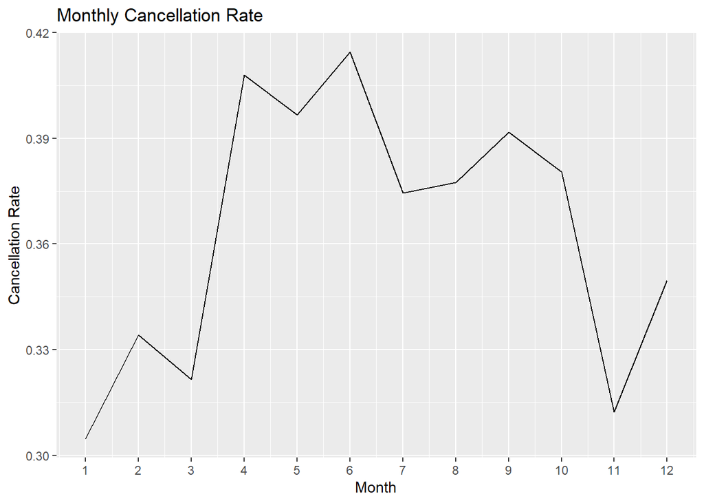

```r
df %>%
  mutate(month_num = as.integer(format(arrival_date, "%m"))) %>%
  group_by(month_num) %>%
  summarise(cancellation_rate = mean(is_canceled)) %>%
  ggplot(aes(x = month_num, y = cancellation_rate)) +
  geom_line() +
  scale_x_continuous(breaks = 1:12) +
  labs(title = "Monthly Cancellation Rate", x = "Month", y = "Cancellation Rate")
```

The following table lists the monthly cancellation rates with three decimal places, offering a precise comparison of cancellation behaviors across the year.

```r
# Compute monthly cancellation rate
monthly_cancellation <- df %>%
  mutate(month_num = as.integer(format(arrival_date, "%m"))) %>%
  group_by(month_num) %>%
  summarise(cancellation_rate = mean(is_canceled), .groups = "drop") %>%
  arrange(month_num)

# Display the summary table
knitr::kable(monthly_cancellation, digits = 3, caption = "Monthly Booking Cancellation Rate")
```

Table 3.2: Monthly Booking Cancellation Rate

| month_num | cancellation_rate |
| --- | --- |
| 1 | 0.305 |
| 2 | 0.334 |
| 3 | 0.322 |
| 4 | 0.408 |
| 5 | 0.397 |
| 6 | 0.415 |
| 7 | 0.375 |
| 8 | 0.378 |
| 9 | 0.392 |
| 10 | 0.380 |
| 11 | 0.312 |
| 12 | 0.350 |

This plot visualizes the Pearson correlation coefficients among selected numeric features, helping to identify potential relationships and multicollinearity between variables.

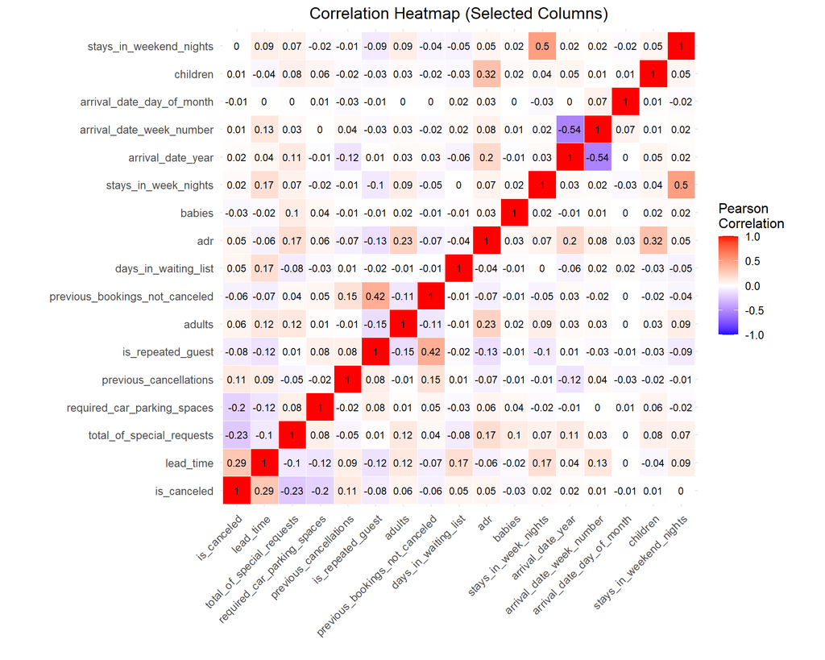

```r
library(ggplot2)
library(dplyr)
library(reshape2)

# Manually select numeric columns for correlation analysis
cols_to_include <- c(
  "is_canceled",
  "lead_time",
  "total_of_special_requests",
  "required_car_parking_spaces",
  # "booking_changes",
  "previous_cancellations",
  "is_repeated_guest",
  # "company",
  "adults",
  "previous_bookings_not_canceled",
  "days_in_waiting_list",
  # "agent",
  "adr",
  "babies",
  "stays_in_week_nights",
  "arrival_date_year",
  "arrival_date_week_number",
  "arrival_date_day_of_month",
  "children",
  "stays_in_weekend_nights"
)

# Filter and remove rows with NA values
numeric_df <- df %>%
  select(all_of(cols_to_include)) %>%
  na.omit()

# Compute correlation matrix and reshape for ggplot2
cor_matrix <- cor(numeric_df)
cor_long <- melt(cor_matrix)

# Create heatmap
ggplot(cor_long, aes(x = Var1, y = Var2, fill = value)) +
  geom_tile(color = "white") +
  scale_fill_gradient2(low = "blue", mid = "white", high = "red",
                       midpoint = 0, limit = c(-1, 1), space = "Lab",
                       name = "Pearson\nCorrelation") +
  geom_text(aes(label = round(value, 2)), size = 3) +
  theme_minimal(base_size = 12) +
  theme(axis.text.x = element_text(angle = 45, vjust = 1, hjust = 1),
        plot.title = element_text(hjust = 0.5)) +
  coord_fixed() +
  labs(title = "Correlation Heatmap (Selected Columns)",
       x = "", y = "")
```

## 3.8 Top 5 Features Most Correlated with Cancellation

To better understand which features influence booking cancellations, we extract the top five variables most correlated with the is_canceled label.

```r
# Compute correlation matrix
numeric_df <- df %>% select(all_of(cols_to_include)) %>% na.omit()
cor_matrix <- cor(numeric_df)

# Extract correlation with the target variable "is_canceled" (excluding itself)
cor_target <- cor_matrix["is_canceled", ]
cor_target <- cor_target[names(cor_target) != "is_canceled"]

# Sort by absolute value of correlation
top_5 <- sort(abs(cor_target), decreasing = TRUE)[1:5]

# Retrieve original signed correlation coefficients
top_5_named <- cor_target[names(top_5)]

# Print top 5 correlated features
print(round(top_5_named, 3))
```

```
##                   lead_time   total_of_special_requests
##                       0.293                      -0.235
## required_car_parking_spaces      previous_cancellations
##                      -0.195                       0.110
##           is_repeated_guest
##                      -0.085
```

# 4 Analysis Process Designed for the Problem

## 4.1 Selected Data Mining Methods and Rationale

In this study, we utilize **XGBoost** and **CatBoost** as the primary data mining methods.

**XGBoost** is a gradient boosting algorithm based on decision trees. It enhances performance by sequentially adding new trees to correct the residuals of previous ones, gradually improving the overall model. For prediction, input data is passed through all trees, each contributing a score based on the leaf node it lands in. The final prediction is the sum of these scores. XGBoost also supports automatic handling of missing values, parallel computation, and includes regularization to mitigate overfitting.

**CatBoost**, on the other hand, is specifically optimized for categorical features. Unlike conventional gradient boosting methods, CatBoost builds **symmetric trees** with uniform splitting structures. A major advantage lies in its internal **target encoding** mechanism, which estimates the likelihood of the target variable based on category membership. This reduces the need for manual encoding. Furthermore, **combinatorial categorical encoding** is used to improve generalization, making CatBoost particularly effective for datasets rich in categorical variables.

We selected these models for their proven **accuracy, efficiency, and robustness** in handling complex feature structures, including temporal and seasonal patterns common in tourism datasets.

## 4.2 Model Evaluation Method

Two data partitioning strategies were employed to ensure reliable model evaluation.

- The **first strategy** designates data from late 2015 to the end of 2016 as the **training set**, with 25% of that portion allocated as a **validation set**, segmented using **monthly time blocks**. Data from **January to June 2017** forms the **test set**.
- The **second strategy** performs a random split, allocating **75%** of the data for training and **25%** for testing, followed by a **5-fold cross-validation** to assess model generalizability.

Given the temporal nature of hotel bookings, we structured data using **month/year blocks** to better capture seasonal trends and forecast future behavior.

To evaluate model performance comprehensively, we employed **accuracy**, **recall**, and **precision**. The **ROC curve** was also used to compare classifiers under different thresholds, and **confusion matrices** were analyzed to identify potential biases or misclassification patterns. This multi-metric approach ensures our models are not only accurate but also practically useful in reducing real-world booking cancellation risks.

## 4.3 Platforms and Tools Used

- **Operating System**: Windows 10, 11
- **Development Environment**: RStudio
- **Programming Language**: R

**Main Libraries**: - `ggplot2` – Data visualization  
- `caret` – Model training and evaluation  
- `dplyr`, `data.table` – Data manipulation  
- `xgboost`, `catboost` – Machine learning modeling  
- Additional packages: `readr`, `lubridate`, `pROC`, etc.

These tools offered a reliable and efficient environment for processing, training, and visualizing the hotel booking dataset.

## 4.4 Research Workflow and Explanation

- **Data Preprocessing**:  
  Columns causing data leakage (e.g., `reservation_status`, `reservation_status_date`) were removed. Columns with limited analytical value or excessive missing data (e.g., `company`, `country`, `agent`) were also dropped. Missing values in numerical features were imputed with the **median**, while categorical features were filled using either the **most frequent value** or a placeholder such as `"Unknown"`. Date fields were properly formatted, and extreme values were handled via clipping or transformation.
- **Feature Selection & Visualization**:  
  Important features were selected using **Information Gain** and **SHAP (SHapley Additive exPlanations)**, retaining **15 top variables**. Visualizations were used to explore distributions and correlations, aiding interpretability.
- **Model Training & Evaluation**:  
  We trained both XGBoost and CatBoost, and visualized decision trees to understand the model’s logic. Evaluation used both standard metrics and visual diagnostic tools.
- **Conclusion**:  
  The final analysis compares model performance against the study’s objectives and offers suggestions for future research improvements.

## 4.5 Workflow Diagram

[interactive chart not shown]

# 5 Analysis Results

## 5.1 Introduction to Experiments and Prior Knowledge

In this experiment, the selected dataset includes records from two different hotel types: **Resort Hotel** and **City Hotel**. As a result, we split the dataset by hotel type and train models separately for each. Furthermore, the dataset suffers from class imbalance, particularly between the `canceled` and `not canceled` booking classes. To address this issue, we apply **SMOTE** (Synthetic Minority Over-sampling Technique) and **DownSampling** methods after splitting the dataset.

The sampling ratios used for SMOTE and DownSampling are summarized in **Table 5.1**:

Table 5.1: Sampling Ratios for SMOTE and DownSampling

| Method | Hotel | Cancel…Not.Canceled |
| --- | --- | --- |
| SMOTE | Resort Hotel | 1 : 0.6 |
| SMOTE | City Hotel | 1 : 0.8 |
| DownSample | Resort Hotel | 1.5 : 1 |
| DownSample | City Hotel | 1.2 : 1 |

We adopted two strategies for splitting the dataset:

### 5.1.1 Method 1: Time-Based Splitting

We considered temporal factors and selected data from 2015 to 2016 as the training set. The test set consists of data from January to June 2017. Following [1], we further split 25% of each month’s data within the training set as a validation set, leaving 75% for model training.

Although [1] proposes fine-tuning the model daily using test set data, which can yield high performance, we believe this approach lacks consideration of time continuity. Nevertheless, it may serve as an upper bound (performance ceiling) for classification performance.

### 5.1.2 Method 2: Random Splitting

We randomly sampled the entire dataset and split it into 75% for training and 25% for testing. To prevent overfitting, we performed **internal validation** within the training set using **5-Fold Stratified Cross Validation**. The final trained model was then evaluated on the test set.

To reduce learning costs and avoid capturing less relevant features in high-dimensional data, we also applied **feature selection**. The methods used include **Information Gain** and **SHAP values**, in conjunction with classical machine learning models for comparison.

In terms of classifiers, we selected **XGBoost** and **CatBoost**, which are boosting-based models that integrate multiple weak classifiers to improve performance.

In the following sections, we will compare model performance across different dataset splits, classifiers, and feature selection strategies using various evaluation metrics, followed by an in-depth analysis.

## 5.2 XGBoost

### 5.2.1 Using Method I with XGBoost Classifier

Table 5.2: Complete Performance Comparison: XGBoost with Method I

| Hotel | Method | Dataset | Accuracy | Precision | Recall | F1_Score | AUC |
| --- | --- | --- | --- | --- | --- | --- | --- |
| Resort Hotel | SMOTE | Validation | 0.8125 | 0.6486 | 0.6575 | 0.6531 | 0.8544 |
| Resort Hotel | SMOTE | Test | 0.8028 | 0.6779 | 0.5665 | 0.6172 | 0.8463 |
| Resort Hotel | DownSample | Validation | 0.8051 | 0.6282 | 0.6712 | 0.6490 | 0.8520 |
| Resort Hotel | DownSample | Test | 0.7920 | 0.6283 | 0.6338 | 0.6310 | 0.8470 |
| City Hotel | SMOTE | Validation | 0.8113 | 0.8098 | 0.7062 | 0.7544 | 0.8404 |
| City Hotel | SMOTE | Test | 0.7567 | 0.7523 | 0.6737 | 0.7108 | 0.8181 |
| City Hotel | DownSample | Validation | 0.7977 | 0.7801 | 0.7062 | 0.7413 | 0.8404 |
| City Hotel | DownSample | Test | 0.7509 | 0.7379 | 0.6804 | 0.7080 | 0.8181 |

Table 5.2: Performance Gap Analysis: Validation vs Test (Percentage Points)

| Hotel | Method | Accuracy Gap (%) | AUC Gap (%) |
| --- | --- | --- | --- |
| Resort Hotel | SMOTE | 0.97 | 0.81 |
| Resort Hotel | DownSample | 1.31 | 0.50 |
| City Hotel | SMOTE | 5.46 | 2.23 |
| City Hotel | DownSample | 4.68 | 2.23 |

### 5.2.2 Using Method I with XGBoost Classifier with SHAP

Table 5.3: Complete Performance Comparison: XGBoost with Method I with SHAP

| Hotel | Method | Dataset | Accuracy | Precision | Recall | F1_Score | AUC |
| --- | --- | --- | --- | --- | --- | --- | --- |
| Resort Hotel | SMOTE | Validation | 0.8051 | 0.6515 | 0.5890 | 0.6187 | 0.8512 |
| Resort Hotel | SMOTE | Test | 0.7922 | 0.6539 | 0.5513 | 0.5982 | 0.8292 |
| Resort Hotel | DownSample | Validation | 0.7831 | 0.5897 | 0.6301 | 0.6093 | 0.8522 |
| Resort Hotel | DownSample | Test | 0.7756 | 0.5911 | 0.6498 | 0.6190 | 0.8296 |
| City Hotel | SMOTE | Validation | 0.7607 | 0.7157 | 0.6919 | 0.7036 | 0.8060 |
| City Hotel | SMOTE | Test | 0.7494 | 0.7293 | 0.6923 | 0.7104 | 0.8203 |
| City Hotel | DownSample | Validation | 0.7451 | 0.6835 | 0.7062 | 0.6946 | 0.8060 |
| City Hotel | DownSample | Test | 0.7435 | 0.7140 | 0.7042 | 0.7091 | 0.8203 |

Table 5.3: Performance Gap Analysis: Validation vs Test (Percentage Points)

| Hotel | Method | Accuracy Gap (%) | AUC Gap (%) |
| --- | --- | --- | --- |
| Resort Hotel | SMOTE | 1.29 | 2.20 |
| Resort Hotel | DownSample | 0.75 | 2.26 |
| City Hotel | SMOTE | 1.13 | -1.43 |
| City Hotel | DownSample | 0.17 | -1.43 |

### 5.2.3 Using Method II with XGBoost Classifier

Table 5.4: Complete Performance Comparison: XGBoost with Method II

| Hotel | Method | Dataset | Accuracy | Precision | Recall | F1_Score | AUC |
| --- | --- | --- | --- | --- | --- | --- | --- |
| Resort Hotel | SMOTE | Validation | 0.8179 | 0.6764 | 0.6599 | 0.6680 | 0.8728 |
| Resort Hotel | SMOTE | Test | 0.8182 | 0.6702 | 0.6796 | 0.6749 | 0.8755 |
| Resort Hotel | DownSample | Validation | 0.7838 | 0.5803 | 0.7998 | 0.6726 | 0.8733 |
| Resort Hotel | DownSample | Test | 0.7450 | 0.5245 | 0.8723 | 0.6551 | 0.8757 |
| City Hotel | SMOTE | Validation | 0.8227 | 0.8474 | 0.7014 | 0.7675 | 0.8882 |
| City Hotel | SMOTE | Test | 0.8205 | 0.8453 | 0.6973 | 0.7642 | 0.8871 |
| City Hotel | DownSample | Validation | 0.8220 | 0.8384 | 0.7103 | 0.7691 | 0.8886 |
| City Hotel | DownSample | Test | 0.8061 | 0.7548 | 0.7930 | 0.7734 | 0.8890 |

Table 5.4: Performance Gap Analysis: Validation vs Test (Percentage Points)

| Hotel | Method | Accuracy Gap (%) | AUC Gap (%) |
| --- | --- | --- | --- |
| Resort Hotel | SMOTE | -0.03 | -0.27 |
| Resort Hotel | DownSample | 3.88 | -0.23 |
| City Hotel | SMOTE | 0.23 | 0.11 |
| City Hotel | DownSample | 1.59 | -0.04 |

### 5.2.4 Using Method II with XGBoost Classifier with SHAP

Table 5.5: Complete Performance Comparison: XGBoost with Method II with SHAP

| Hotel | Method | Dataset | Accuracy | Precision | Recall | F1_Score | AUC |
| --- | --- | --- | --- | --- | --- | --- | --- |
| Resort Hotel | SMOTE | Validation | 0.8279 | 0.7068 | 0.6496 | 0.6770 | 0.8793 |
| Resort Hotel | SMOTE | Test | 0.8265 | 0.6942 | 0.6703 | 0.6820 | 0.8834 |
| Resort Hotel | DownSample | Validation | 0.7917 | 0.5928 | 0.7980 | 0.6803 | 0.8803 |
| Resort Hotel | DownSample | Test | 0.7448 | 0.5240 | 0.8835 | 0.6578 | 0.8842 |
| City Hotel | SMOTE | Validation | 0.8242 | 0.8500 | 0.7028 | 0.7694 | 0.8875 |
| City Hotel | SMOTE | Test | 0.8226 | 0.8474 | 0.7011 | 0.7673 | 0.8876 |
| City Hotel | DownSample | Validation | 0.8228 | 0.8382 | 0.7129 | 0.7705 | 0.8885 |
| City Hotel | DownSample | Test | 0.8079 | 0.7576 | 0.7936 | 0.7752 | 0.8879 |

Table 5.5: Performance Gap Analysis: Validation vs Test (Percentage Points)

| Hotel | Method | Accuracy Gap (%) | AUC Gap (%) |
| --- | --- | --- | --- |
| Resort Hotel | SMOTE | 0.14 | -0.41 |
| Resort Hotel | DownSample | 4.69 | -0.39 |
| City Hotel | SMOTE | 0.16 | -0.01 |
| City Hotel | DownSample | 1.48 | 0.06 |

## 5.3 CatBoost

### 5.3.1 Using Method I with CatBoost Classifier

Table 5.6: Complete Performance Comparison: CAToost with Method I

| Hotel | Method | Dataset | Accuracy | Precision | Recall | F1_Score | AUC |
| --- | --- | --- | --- | --- | --- | --- | --- |
| Resort Hotel | SMOTE | Validation | 0.7978 | 0.6250 | 0.6164 | 0.6207 | 0.8538 |
| Resort Hotel | SMOTE | Test | 0.8077 | 0.6950 | 0.5609 | 0.6208 | 0.8459 |
| Resort Hotel | DownSample | Validation | 0.7978 | 0.6286 | 0.6027 | 0.6154 | 0.8550 |
| Resort Hotel | DownSample | Test | 0.8097 | 0.7106 | 0.5428 | 0.6154 | 0.8446 |
| City Hotel | SMOTE | Validation | 0.8346 | 0.8987 | 0.6730 | 0.7696 | 0.8742 |
| City Hotel | SMOTE | Test | 0.7734 | 0.7935 | 0.6617 | 0.7216 | 0.8494 |
| City Hotel | DownSample | Validation | 0.8366 | 0.8994 | 0.6777 | 0.7730 | 0.8735 |
| City Hotel | DownSample | Test | 0.7727 | 0.7888 | 0.6665 | 0.7225 | 0.8493 |

Table 5.6: Performance Gap Analysis: Validation vs Test (Percentage Points)

| Hotel | Method | Accuracy Gap (%) | AUC Gap (%) |
| --- | --- | --- | --- |
| Resort Hotel | SMOTE | -0.99 | 0.78 |
| Resort Hotel | DownSample | -1.19 | 1.04 |
| City Hotel | SMOTE | 6.12 | 2.49 |
| City Hotel | DownSample | 6.39 | 2.42 |

### 5.3.2 Using Method I with CAToost Classifier with SHAP

Table 5.7: Complete Performance Comparison: CAToost with Method I with SHAP

| Hotel | Method | Dataset | Accuracy | Precision | Recall | F1_Score | AUC |
| --- | --- | --- | --- | --- | --- | --- | --- |
| Resort Hotel | SMOTE | Validation | 0.7978 | 0.6216 | 0.6301 | 0.6259 | 0.8628 |
| Resort Hotel | SMOTE | Test | 0.8066 | 0.6872 | 0.5709 | 0.6237 | 0.8488 |
| Resort Hotel | DownSample | Validation | 0.7978 | 0.6286 | 0.6027 | 0.6154 | 0.8601 |
| Resort Hotel | DownSample | Test | 0.8089 | 0.7080 | 0.5431 | 0.6147 | 0.8489 |
| City Hotel | SMOTE | Validation | 0.8346 | 0.9091 | 0.6635 | 0.7671 | 0.8713 |
| City Hotel | SMOTE | Test | 0.7706 | 0.7945 | 0.6518 | 0.7161 | 0.8402 |
| City Hotel | DownSample | Validation | 0.8230 | 0.8704 | 0.6682 | 0.7560 | 0.8735 |
| City Hotel | DownSample | Test | 0.7671 | 0.7823 | 0.6588 | 0.7153 | 0.8408 |

Table 5.7: Performance Gap Analysis: Validation vs Test (Percentage Points)

| Hotel | Method | Accuracy Gap (%) | AUC Gap (%) |
| --- | --- | --- | --- |
| Resort Hotel | SMOTE | -0.89 | 1.41 |
| Resort Hotel | DownSample | -1.11 | 1.12 |
| City Hotel | SMOTE | 6.40 | 3.11 |
| City Hotel | DownSample | 5.58 | 3.27 |

### 5.3.3 Using Method II with CAToost Classifier

Table 5.8: Complete Performance Comparison: CAToost with Method II

| Hotel | Method | Dataset | Accuracy | Precision | Recall | F1_Score | AUC |
| --- | --- | --- | --- | --- | --- | --- | --- |
| Resort Hotel | SMOTE | Validation | 0.8138 | 0.6825 | 0.6160 | 0.6475 | 0.8711 |
| Resort Hotel | SMOTE | Test | 0.7974 | 0.6171 | 0.7123 | 0.6613 | 0.8703 |
| Resort Hotel | DownSample | Validation | 0.8138 | 0.6825 | 0.6160 | 0.6475 | 0.8711 |
| Resort Hotel | DownSample | Test | 0.7974 | 0.6171 | 0.7123 | 0.6613 | 0.8703 |
| City Hotel | SMOTE | Validation | 0.8142 | 0.8531 | 0.6701 | 0.7506 | 0.8788 |
| City Hotel | SMOTE | Test | 0.8168 | 0.8443 | 0.6878 | 0.7580 | 0.8796 |
| City Hotel | DownSample | Validation | 0.8142 | 0.8531 | 0.6701 | 0.7506 | 0.8788 |
| City Hotel | DownSample | Test | 0.8168 | 0.8443 | 0.6878 | 0.7580 | 0.8796 |

Table 5.8: Performance Gap Analysis: Validation vs Test (Percentage Points)

| Hotel | Method | Accuracy Gap (%) | AUC Gap (%) |
| --- | --- | --- | --- |
| Resort Hotel | SMOTE | 1.64 | 0.08 |
| Resort Hotel | DownSample | 1.64 | 0.08 |
| City Hotel | SMOTE | -0.26 | -0.07 |
| City Hotel | DownSample | -0.26 | -0.07 |

### 5.3.4 Using Method II with CAToost Classifier with SHAP

Table 5.9: Complete Performance Comparison: CAToost with Method II with SHAP

| Hotel | Method | Dataset | Accuracy | Precision | Recall | F1_Score | AUC |
| --- | --- | --- | --- | --- | --- | --- | --- |
| Resort Hotel | SMOTE | Validation | 0.8108 | 0.6713 | 0.6242 | 0.6469 | 0.8738 |
| Resort Hotel | SMOTE | Test | 0.7958 | 0.6042 | 0.7670 | 0.6760 | 0.8743 |
| Resort Hotel | DownSample | Validation | 0.8108 | 0.6713 | 0.6242 | 0.6469 | 0.8738 |
| Resort Hotel | DownSample | Test | 0.7958 | 0.6042 | 0.7670 | 0.6760 | 0.8743 |
| City Hotel | SMOTE | Validation | 0.8146 | 0.8538 | 0.6704 | 0.7510 | 0.8791 |
| City Hotel | SMOTE | Test | 0.8149 | 0.8450 | 0.6814 | 0.7544 | 0.8793 |
| City Hotel | DownSample | Validation | 0.8146 | 0.8538 | 0.6704 | 0.7510 | 0.8791 |
| City Hotel | DownSample | Test | 0.8149 | 0.8450 | 0.6814 | 0.7544 | 0.8793 |

Table 5.9: Performance Gap Analysis: Validation vs Test (Percentage Points)

| Hotel | Method | Accuracy Gap (%) | AUC Gap (%) |
| --- | --- | --- | --- |
| Resort Hotel | SMOTE | 1.50 | -0.05 |
| Resort Hotel | DownSample | 1.50 | -0.05 |
| City Hotel | SMOTE | -0.04 | -0.02 |
| City Hotel | DownSample | -0.04 | -0.02 |

### 5.3.5 CatBoost + SHAP Summary of Findings

# 6 Conclusion and Future Directions

## 6.1 Summary of Findings

### 6.1.1 Model Comparison Summary: XGBoost vs. CatBoost

Ultimately, the **choice between models should depend on business priorities**:

- If the goal is to **maximize recall** and reduce missed cancellations, **XGBoost** is preferable.
- If the focus is on **overall predictive balance** or precision, **CatBoost** may be more appropriate.

This insight enables data-driven model selection tailored to specific operational objectives in hotel booking management.

### 6.1.2 Strategy Comparison: Method I vs. Method II

A comparison between Method I and Method II reveals that **Method II consistently outperforms Method I**, particularly in **recall and AUC** across both resort and city hotel datasets. These improvements underscore Method II’s ability to identify cancellations more effectively, making it better suited for high-sensitivity applications.

While Method I shows slightly higher accuracy in the resort hotel setting, the difference is marginal and does not outweigh the recall advantage offered by Method II. In both hotel types, **Method II demonstrates stronger robustness and generalization**, achieving better balance between sensitivity and predictive power.

**Therefore, Method II is the preferred strategy when the primary objective is to minimize false negatives and enhance cancellation detection performance.**

## 6.2 Limitations of the Current Approach

**Limited Data Coverage** The dataset only extends to July 2017, making it unable to capture recent travel trends, post-pandemic behaviors, and evolving customer patterns.

**Challenges in Model Maintenance** Updating the model daily requires intensive computation and full data preprocessing, which adds to the maintenance burden and resource demand.

## 6.3 Proposed Modifications

**Use Stratified Random Sampling for Data Splitting**

- Maintains a balanced class distribution (e.g., canceled vs. not canceled) across both training and testing sets.
- Reduces the complexity of time-based split logic.
- Enhances the pipeline’s scalability and ease of update with new data.

**Key Benefits**

- Improved class balance consistency across subsets
- Easier automation and ongoing maintenance
- Greater model robustness and more reliable evaluation

## 6.4 Future Work

- Extend the dataset to include post-2017 records, especially covering the COVID-19 impact period
- Experiment with advanced models such as LSTM or Transformer architectures for time-aware predictions
- Integrate real-time data streams and develop dashboards for operational use
- Deploy models in production environments and conduct A/B testing to assess business impact

# 7 References

[1]

N. Antonio, A. de Almeida, and L. Nunes, “Predicting hotel bookings cancellation with a machine learning classification model,” in *2017 16th IEEE international conference on machine learning and applications (ICMLA)*, Cancun, Mexico, 2017, pp. 1049–1054.

[2]

N. Antonio, A. de Almeida, and L. Nunes, “Hotel booking demand datasets,” *Data in Brief*, vol. 22, p. 41, 2019.

# 8 Appendix

## 8.1 Project Repository

Source code and materials:  
https://github.com/cyc6221/Hotel-Booking-Cancellation-Prediction